# Plant-pollinator specialization: Origin and measurement of curvature

#### 3. What is curvature?

Reviewing the literature leads us to ask, “what is curvature?”. There are at least four definitions in use within pollination ecology, with few references to their mathematical origins. Ultimately, curvature is a concept most studied by geometers. Turning to the field of geometry we find several definitions resulting from a history of independent derivations (reviewed in Coolidge, 1952; Bardini and Gianella, 2016). However, these definitions share a conceptual theme: curvature is a point-wise property that can measured anywhere on a line. This concept is a refinement to those reviewed in the previously, where curvature is single property of an entire shape. Here, we follow the conventions of Casey (1996) and Rutter (2000), and present a definition of curvature that is tractable for analyzing biological shapes.

Intuitively, when a line deviates from being straight we say it is curved, the extent to which it is not straight is its curvature. More technically, a line deviates from being straight when its first derivative - the tangent (shown by $\mathbf{T}_0$, $\mathbf{T}_2$, $\mathbf{T}_n$ in Figure 3) - changes direction (e.g. the difference in direction of $\mathbf{T}_i$ to $\mathbf{T}_{i+1}$. Therefore, curvature can be thought of as the rate of change in the tangent as we move across the curve. Hence, the tangents of a straight line will have the same direction everywhere and a curvature of zero, whereas the tangents of the curve shown in Figure 3 will change direction and have a non-zero curvature.

To formalize these concepts mathematically we begin by considering an ordinary function of the form $y=f(x)$, where $f(x)$ specifies one value of $y$ for each value of $x$. Biological curves, however, often loop back on themselves (e.g. spirals) and are better described by parametric fuctions that allow the curve to have multiple $y$ values for a single $x$. Parametric functions use a ‘hidden’ variable that determines the values of $x$ and $y$ independently. Here, we use the parameter variable arc length, $s$, along the curve. Letting $\mathbf{\bar{r}}_i$ be the position $(x_i, y_i)$, we can express $\mathbf{\bar{r}}_i$ as a function solely of $s_i$. Specifically, using vector notation we have:

$$\begin{equation}
\tag{1}
\mathbf{\bar{r}}(s_i) =
\mathbf{\bar{r}}_i \equiv \left[\begin{array}
{rrr}
x(s_i) \\
y(s_i) \\
\end{array}\right]
\end{equation}$$

Where $\mathbf{\bar{r}}_i$ is shorthand for $\mathbf{\bar{r}}(s_i)$ which indicates that our position $(x_i, y_i)$ on the curve is determined by the length of the segment $s_i$. Although we could parameterize a curve by many potential parametric variables, arc length is a convienient choice because it allows us to move along the curve at even increments, which we denote as $\Delta s$. This proves useful when taking repeated, equally-spaced measurements along a curve, such as curvature.

As we are interested in the derivative properties of our arc-length parameterized curve, we can differentiate $\mathbf{\bar{r}}(s)$ with respect to arc length $s$ in the following way (using the formal definition of the derivative):

$$\begin{equation}
\tag{2}
\lim\limits_{\Delta s \to 0} \frac{\Delta \mathbf{\bar{r}}(s)}{\Delta s} = \frac{d \mathbf{\bar{r}}(s)}{ds} = \mathbf{T}(s)
\end{equation}$$

This produces a tangent function $\mathbf{T}(s) = \frac{d \mathbf{\bar{r}}}{ds}$ giving the first derivative of the parametric equation $\mathbf{\bar{r}}(s)$. The tangent $\mathbf{T}_i = \mathbf{T}(s_i)$ contains information about the direction of the curve at position $\mathbf{\bar{r}}(s_i)$ that we will use to calculate curvature.

At the beginning of this section we defined curvature, $\kappa$, as the rate at which the tangent is changing direction. We can now formalize this by differentiating $\mathbf{T}$ with respect to arc length:

$$\begin{equation}
\tag{3}
\kappa = \frac{d \mathbf{T}}{ds}
\end{equation}$$

Where $\frac{d \mathbf{T}}{ds}$ is the second derivative of the parameteric function $\mathbf{\bar{r}}(s_i)$:

$$\begin{equation}
\tag{4}
\kappa_i = \lim\limits_{\Delta s \to 0} \frac{\mathbf{T}_i - \mathbf{T}_{i- \Delta s}}{\Delta s} = \frac{d \mathbf{T}_i}{ds}
\end{equation}$$

$$\begin{equation}
\tag{5}
\mathbf{T_i} =
\left[\begin{array}
{rrr}
x(s_i) \\
y(s_i) \\
\end{array}\right] =
\left[\begin{array}
{rrr}
cos(\phi_i) \\
sin(\phi_i) \\
\end{array}\right]
\end{equation}$$

Where:

$$\begin{equation}
\tag{6}
\tan(\phi_i) = \frac{y(s_i)}{x(s_i)}
\end{equation}$$

And:

$$\begin{equation}
\tag{7}
\phi_i = \arctan{\frac{y(s_i)}{x(s_i)}}
\end{equation}$$

Thus, curvature $\kappa$ can be expressed as the change in the angle $\phi$ formed between the tangent $\mathbf{T}$ and the $x$-axis:

$$\begin{equation}
\tag{8}
\kappa = \frac{d \mathbf{T}}{ds} = \frac{d\phi}{ds}
\end{equation}$$

This definition provides an intuitive unit of measurement for reporting curvature: degrees of rotation per unit arc length (Figure 4). For example, if arc length has been measured in millimeters, we would report its curvature as degrees per millimeter $degrees \cdot mm^{-1}$. Framed this way curvature is a measure of rotation per distance. In contrast to previous defintions, where curvature is an indivisble, single property of an entire shape, here, curvature is a property of every point along the curve. Under our point-wise defintion, we can summarize the *total curvature* (Milnor, 1954) of a specimen as the of sum the individual curvature measurements made along the curve:

$$\begin{equation}
\tag{6}
\kappa_{total} = \int_{0}^{s_{max}} \kappa \; ds
\end{equation}$$

Units for *total curvature* are no longer expressed as $degrees \cdot mm^{-1}$ because we are not measuring curvature at a single point. Instead we are summarizing all tangent rotations along the curve, expressed simply as $degrees$.

To account for size variation between specimens, we propose using *total adjusted curvature*, that is, total curvature divided by arc length:

$$\begin{equation}
\tag{7}
\kappa_{adj} = \frac{\kappa_{total}}{s_{max}}
\end{equation}$$

Units for $\kappa_{adj}$ are expressed as $degrees \cdot mm^{-1}$. *Total adjusted curvature* also represents mean curvature of the curve.

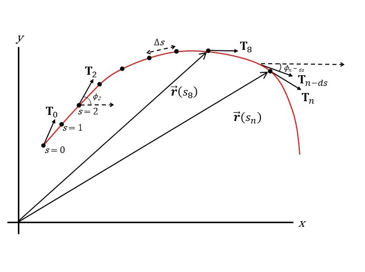

#### 4. A proposed protocol for measuring curvature

As illustrated in the methodology review, our current protocols for measuring flower-pollinator curvature lack a conceptual unity. In each method, curvature takes on a new meaning. Therefore, there are two main advantages of the curvature definition described above. First, curvature becomes a local property of the tissue or organ under study. This means that shape information is gathered at every point along the curve and can be examined and compared to other points within or between specimens. This differs from previous methods that take curvature as a total property of the entire curve. In previous methods curvature cannot be parsed into smaller elements. Second, because the revised definition is explicitly adapted from the field of differential geometry, we benefit from citeable geometric concepts that allow us to be clear about what we mean by ‘curvature’.

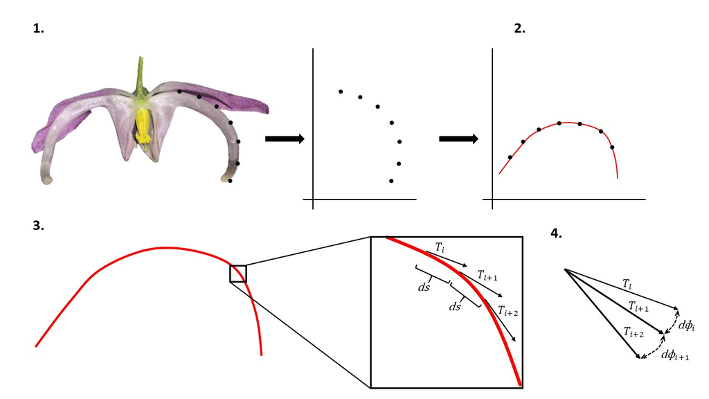

Figure 4: Proposed protocol for measuring curvature. 1. A petal of *Epimedium violaceum* is landmarked and rotated. 2. A polynomial curve is fitted to the landmarks. 3. Curvature is calculated as the rate of change of the tangent vector at every point along the curve. Total curvature can be calculated by the methods outlined in Section 3.

Adams, D.C., Rohlf, F.J., and Slice, D.E. (2013). A field comes of age: Geometric morphometrics in the 21st century. Hystrix *24*, 7.

Bardini, G., and Gianella, G.M. (2016). A historical walk along the idea of curvature, from Newton to Gauss passing from Euler. International Mathematical Forum *11*, 259–278.

Casey, J. (1996). Exploring curvature (Braunschweig, Germany: Friedr. Vieweg & Sohn Verlagsgesellschaft mbH).

Coolidge, J.L. (1952). The unsatisfactory story of curvature. The American Mathematical Monthly *59*, 375–379.

Cosgrove, D.J. (1990). Rapid, bilateral changes in growth rate and curvature during gravitropism of cucumber hypocotyls: Implications for mechanism of growth control. Plant, Cell & Environment *13*, 227–234.

Milnor, J. (1954). On total curvatures of closed space curves. Mathematica Scandinavica *1*, 289–296.

Rutter, J.W. (2000). Geometry of curves (Boca Raton, FL: CRC Press, Taylor; Francis Group).

Terral, J.-F., Alonso, N., Capdevila, R.B. i, Chatti, N., Fabre, L., Fiorentino, G., Marinval, P., Jordá, G.P., Pradat, B., Rovira, N., et al. (2004). Historical biogeography of olive domestication (olea europaea l.) as revealed by geometrical morphometry applied to biological and archaeological material. Journal of Biogeography *31*, 63–77.